# Introduction to flowUtilities

John Edgar

2025-11-29

## Overview

This vignette demonstrates how to use `flowUtilities` to simplify flow cytometry data analysis workflows. The package makes use of the Bioconductor libraries [flowCore](https://www.bioconductor.org/packages/release/bioc/html/flowCore.html), flowWorkspace, and [flowStats](https://bioconductor.org/packages/release/bioc/html/flowStats.html) to streamline data import, gating, visualization, and statistical analysis.

## Load data and apply compensation

The example data is from human postnatal thymus that were stained with CD3, CD4, CD8a, CD27, CCR7, and TCRαβ antibodies. It includes two samples and six fluorescent-minus-one controls. We can read the .fcs files into a `flowWorkspace::cytoset` object.

```r
library(flowWorkspace)
library(flowCore)
library(flowUtilities)

dir <- system.file("extdata", package="flowUtilities")
files <- list.files(dir, pattern = ".fcs",full.names = TRUE)

# Load cytoset
cs <- load_cytoset_from_fcs (files)
cs
```

```
#> A cytoset with 8 samples.
#>
#>   column names:
#>     FSC-H, FSC-A, SSC-H, SSC-A, FL1-H, FL1-A, FL2-H, FL2-A, FL3-H, FL3-A, FL4-H, FL4-A, FL5-H, FL5-A, FL6-H, FL6-A, FL7-H, FL7-A, FL8-H, FL8-A, FL9-H, FL9-A, FL10-H, FL10-A, FL11-H, FL11-A, FL12-H, FL12-A, FL13-H, FL13-A, FL14-H, FL14-A, FL15-H, FL15-A, FL16-H, FL16-A, FL17-H, FL17-A, FL18-H, FL1…
```

The compensation was calculated with the cytometer software and the spill matrices stored in the .fcs files. We can use `apply_compensation_from_fcs` to find them and apply compensation to the data.

```r
cs <- apply_compensation_from_fcs(cs)
```

The channel names used by the cytometer have the format “FLn-A”, “FLn-H” recording the area and height, respectively. We don’t need the height channels and can remove them using `filter_channels`. Again, we’ll use a regular expression to exclude all channels using the pattern “FL” followed by one or more digits “`\\d+`” then “-H”.

```r
cs <- filter_channels(cs, exclude="FL\\d+-H")
```

```
#> Filterning complete
#> Channels kept:
#> FSC-H
#> FSC-A
#> SSC-H
#> SSC-A
#> FL1-A
#> FL2-A
#> FL3-A
#> FL4-A
#> FL5-A
#> FL6-A
#> FL7-A
#> FL8-A
#> FL9-A
#> FL10-A
#> FL11-A
#> FL12-A
#> FL13-A
#> FL14-A
#> FL15-A
#> FL16-A
#> FL17-A
#> FL18-A
#> FL19-A
#> FSC-Width
#> Time
```

## Adding metadata from filenames

This data was collected using a CytoFlex LX cytometer. The resultant .fcs file names have the format “01-MySample-A1.fcs”, where “01” is the plate ID, “MySample” is the sample ID, and “A1” is the well (or tube) ID. In this example, the sample ID includes details to identify the type (sample or FMO control) that will be useful later.

We can extract all of this metadata from the file names using [regular expressions](https://cran.r-project.org/web/packages/stringr/vignettes/regular-expressions.html) and add it to the phenoData contained in the `GatingSet` object. This will allow us to select samples or groups of samples for plotting or further analysis.

```r
cs <- read_names_to_pdata(cs,
                          sample = "(?<=\\d{2}-)(.+?)(?=(-[A-Z]{1}\\d{1,2}.fcs))",
                          group = "(?i)fmo|sample",
                          fmo = "CD\\d+[A-z]*|TCR[A-z]{2}|CCR7|ZOMBIE-UV")
```

|  | name | sample | group | fmo |
| --- | --- | --- | --- | --- |
| 01-FMO_CCR7-C5.fcs | 01-FMO_CCR7-C5.fcs | FMO_CCR7 | FMO | CCR7 |
| 01-FMO_CD27-C8.fcs | 01-FMO_CD27-C8.fcs | FMO_CD27 | FMO | CD27 |
| 01-FMO_CD3-C7.fcs | 01-FMO_CD3-C7.fcs | FMO_CD3 | FMO | CD3 |
| 01-FMO_CD4-B8.fcs | 01-FMO_CD4-B8.fcs | FMO_CD4 | FMO | CD4 |
| 01-FMO_CD8a-B6.fcs | 01-FMO_CD8a-B6.fcs | FMO_CD8a | FMO | CD8a |
| 01-FMO_TCRab-B5.fcs | 01-FMO_TCRab-B5.fcs | FMO_TCRab | FMO | TCRab |
| 01-SAMPLE_A-A4.fcs | 01-SAMPLE_A-A4.fcs | SAMPLE_A | SAMPLE | NA |
| 01-SAMPLE_B-A5.fcs | 01-SAMPLE_B-A5.fcs | SAMPLE_B | SAMPLE | NA |

Regular expressions look a bit unwieldy. A Google search for “R regex cheat sheet” is helpful for writing them.

## Adding informative marker names

The .fcs files contain user-defined marker names (like “CD3”, “CD4”, etc.) that we would like to use instead of “FLn-A”. These marker names also include other details like the laser and filter set that we don’t need. Calling `get_marker_names` with the appropriate regular expression will extract the useful marker names while ignoring the rest. Channels that were recorded but did not include an antibody will be labeled with the default “UNUSED”.

```r
markers <- get_marker_names(cs,
                            "CD\\d+[A-z]*|TCR[A-z]{2}|CCR7|ZOMBIE-UV",
                            default_name = "UNUSED")
```

```
#> FL1-A -> CD4
#> FL2-A -> UNUSED
#> FL3-A -> CD95
#> FL4-A -> TCRgd
#> FL5-A -> CCR7
#> FL6-A -> UNUSED
#> FL7-A -> UNUSED
#> FL8-A -> CD8b
#> FL9-A -> CD27
#> FL10-A -> UNUSED
#> FL11-A -> CD3
#> FL12-A -> CD8a
#> FL13-A -> UNUSED
#> FL14-A -> UNUSED
#> FL15-A -> TCRab
#> FL16-A -> CD45RA
#> FL17-A -> ZOMBIE-UV
#> FL18-A -> UNUSED
#> FL19-A -> UNUSED
```

If we’re happy with the marker names, we can make them the new channel names.

```r
cs <- set_channels_from_markers(cs, markers = markers)
```

## Transforming fluorescent channels

To improve data visualization, we can apply a logicle transformation to fluorescent channels. The `estimateLogicleTransform` function estimates reasonable parameters for the data and returns a `transformerList` to apply to our data. First, we’ll create a `flowWorkspace::GatingSet` object to store our transformation and subsequent gates.

```r
# Make GatingSet
gs <- GatingSet(cs)

# What to transform
markers <- c("CCR7", "CD27", "CD3", "CD4", "CD8a", "TCRab", "ZOMBIE-UV")

# Estimate logicle parameters
transList <- estimateLogicleTransform(gs, channels = markers, m=5)
# Apply transformation to GatingSet
gs <- transform(gs, transList)
```

We can visualize the transformation using `plot_stacked_hist`. We don’t need to plot all of the data, so we’ll use `get_samples_by_keyword` to select only the FMO controls using the phenoData group ID that we added previously.

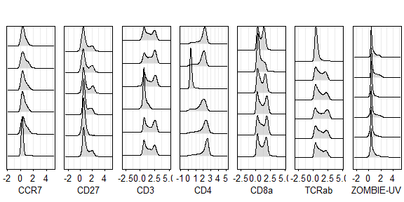

```r
# Retrieve fmos for visualization
gs_fmo <- get_samples_by_keyword(gs, group="FMO")
# Plot
plot_stacked_hist(gs_fmo, markers, nrow = 1)
```

## Building the gating hierarchy

Gating data involves constructing gate objects and sequentially applying them to the `GatingSet` (see the [flowWorkspace vignette](https://www.bioconductor.org/packages/devel/bioc/vignettes/flowWorkspace/inst/doc/flowWorkspace-Introduction.html) for an introduction).

### Boundary filter

Often there are events at or near the detection limit of the cytometer that are uninformative and make setting plot limits a pain. We can apply a `flowCore::rectangleGate` to the FSC-A and SSC-A channels to clean up the data. The `plot_grid` function can be used to visualize the gate.

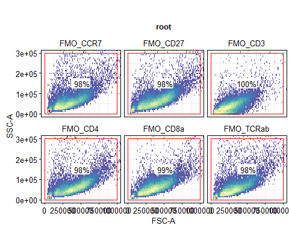

```r
parentID <- "root"
gateID <- "BoundaryFilter"

x_axis <- "FSC-A"
y_axis <- "SSC-A"

# Define gate edges
edges <- list(c(0, 1.0e6),   # FSC-A
              c(0, 0.3e6))   # SSC-A
names(edges) <- c(x_axis, y_axis)

# Create rectangle gate
gate <- flowCore::rectangleGate(edges, filterId = gateID)

# Visualize gate
plot_grid(gs_fmo,
          x_axis,
          y_axis,
          gate,
          limits = edges,
          subset = parentID,
          facet_by = "sample",
          ncol = 3,
          n_bins = 2048)
```

This does not apply the gate to our `GatingSet`. The edge locations can be adjusted and the above code re-run. Once satisfied with the gate, add it to the `GatingSet`.

```r
gs_pop_add(gs, gate, parent=parentID)
```

```
#> [1] 2
```

```r
recompute(gs)
```

### Singlet discrimination

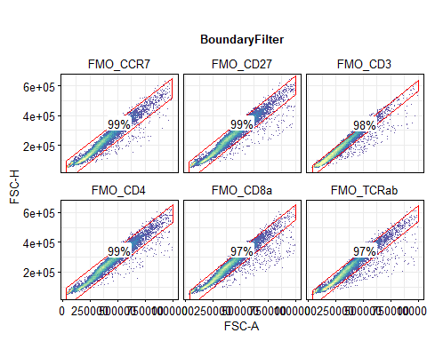

```r
parentID <- "BoundaryFilter"
gateID <- "Singlets"

x_axis <- "FSC-A"
y_axis <- "FSC-H"

# Estimate singlet gates per sample using RLM
gate <- autoSingletGate(gs,
                      area = x_axis,
                      height = y_axis,
                      parentId = parentID,
                      gateId = gateID)

# Visualize gate
plot_grid(gs_fmo,
          x_axis,
          y_axis,
          gate,
          limits = "data",
          subset = parentID,
          facet_by = "sample",
          ncol = 3)
```

Apply the gate.

```r
gs_pop_add(gs, gate, parent=parentID)
```

```
#> [1] 3
```

```r
recompute(gs)
```

### Identify lymphocytes

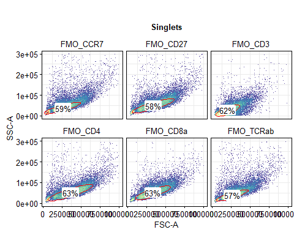

```r
parentID <- "Singlets"
gateID <- "Lymphocytes"

x_axis <- "FSC-A"
y_axis <- "SSC-A"

# Define lymphocyte gate using CD3 preselection
gate <- autoLymphGate(gs,
                      x = x_axis,
                      y = y_axis,
                      preselection = "CD3",
                      parentId = parentID,
                      gateId = gateID)

# Visualize gate
plot_grid(gs_fmo,
          x_axis,
          y_axis,
          gate,
          limits="data",
          subset=parentID,
          facet_by="sample",
          ncol=3)
```

```r
gs_pop_add(gs, gate, parent=parentID)
```

```
#> [1] 4
```

```r
recompute(gs)
```

### Viable cell selection

Use a `flowCore::rectangleGate` to exclude dead cells using the Zombie-UV viability dye.

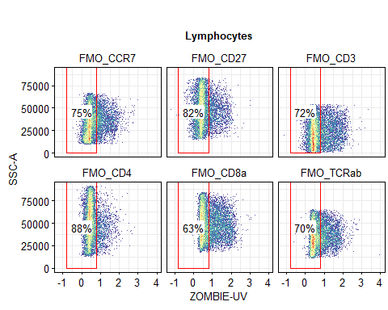

```r
parentID <- "Lymphocytes"
gateID <- "Live"

x_axis <- "ZOMBIE-UV"
y_axis <- "SSC-A"

# Define rectangle gate for live cells
edges <- list(c(-0.8, 0.8),
              c(0, 1.5e5))
names(edges) <- c(x_axis, y_axis)

gate <- flowCore::rectangleGate(edges, filterId=gateID)

# Visualize gate
plot_grid(gs_fmo,
          x_axis,
          y_axis,
          gate,
          limits="data",
          subset=parentID,
          facet_by="sample",
          ncol=3)
```

```r
# Apply gate
gs_pop_add(gs, gate, parent=parentID)
```

```
#> [1] 5
```

```r
recompute(gs)
```

### Identifying T Cells

We can gate T cells based on expression of CD3 and TCRαβ. `diagPolygonGate` is a convenience function for constructing a gate along a diagonal population (it can also be used for singlet discrimination).

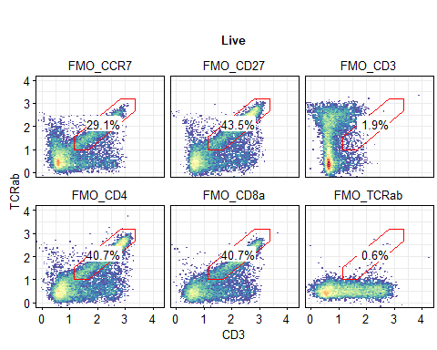

```r
parentID <- "Live"
gateID <- "CD3+TCRab+"

x_axis <- "CD3"
y_axis <- "TCRab"

# Define diagonal polygon gate
gate <- diagPolygonGate(x = x_axis,
                        y = y_axis,
                        width = 2.2,
                        height = 2.2,
                        origin = c(1.15, 1.0),
                        diag_width = 0.75,
                        gateId = gateID)

# Visualize gate
plot_grid(gs_fmo,
          x_axis,
          y_axis,
          gate,
          limits=list(x=c(0, 4.2), y=c(0, 4)),
          subset=parentID,
          facet_by="sample",
          ncol=3)
```

```r
# Apply gate
gs_pop_add(gs, gate, parent=parentID)
```

```
#> [1] 6
```

```r
recompute(gs)
```

### Gate CD4 and CD8 T cell subsets

We can identify CD4+CD8+ (DP), CD4+CD8- (4SP), and CD4-CD8+ (8SP) T cell populations. The “fmo” column in phenoData contains marker names that match the FMO controls to their respective channel. The `autoQuadGate` function can use this information to set threshold of a quadrant gate. It calculates the quantile using each channel’s FMO based on the `probs` argument. The function returns a list containing a `flowCore::quadGate` object and a vector of names to apply to each quadrant population.

```r
parentID <- "CD3+TCRab+"
gateID <- "CD4/CD8"

x_axis <- "CD4"
y_axis <- "CD8a"

# Define quadrant gates using FMO controls
gate <- autoQuadGate(gs,
                     x = x_axis,
                     y = y_axis,
                     probs = 0.99,
                     ctrlId = "fmo",
                     parentId = parentID,
                     gateId = gateID)
```

```
#> $CD4
#> [1] 0.6884761
#>
#> $CD8a
#> [1] 1.576837
```

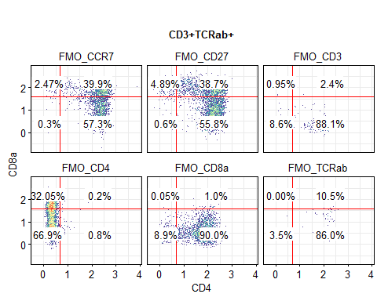

```r
# Visualize gate
plot_grid(gs_fmo,
          x_axis,
          y_axis,
          gate$gate,
          limits="data",
          subset=parentID,
          facet_by="sample",
          ncol=3)
```

```r
# Apply gate
gs_pop_add(gs, gate$gate, parent=parentID, names=gate$names)
```

```
#> [1]  7  8  9 10
```

```r
recompute(gs)
```

## Plot the gating hierarchy for samples

After gating, we can visualize the gating hierarchy using `plot_gating_hierarchy`. This function is intended to save the plots in a directory rather than print to screen. However, we can return the plots to display for a small number of samples.

```r
# Select samples to plot
gs_samp <- get_samples_by_keyword(gs, group="SAMPLE")
```

```
#> 2 samples found:
#> 01-SAMPLE_A-A4.fcs
#> 01-SAMPLE_B-A5.fcs
```

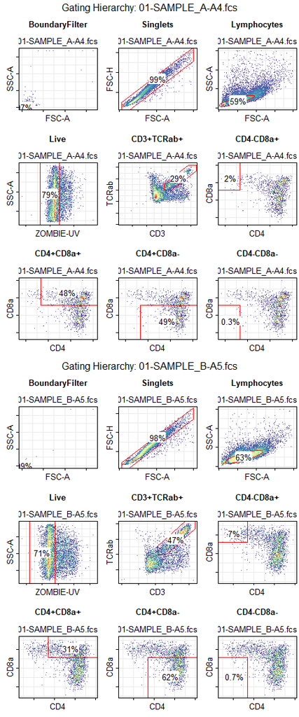

```r
# Plot gating hierarchy
plot_gating_hierarchy(gs_samp,
                      output_dir = NULL,
                      ncol = 3,
                      width = 5,
                      height = 8,
                      limits = "data",
                      remove_axis_ticks = TRUE,
                      top_margin = 0.25,
                      return_plots = TRUE)
```